# EDA of Red Wines quality by Oleksandr Brazhenko

### Plot Three

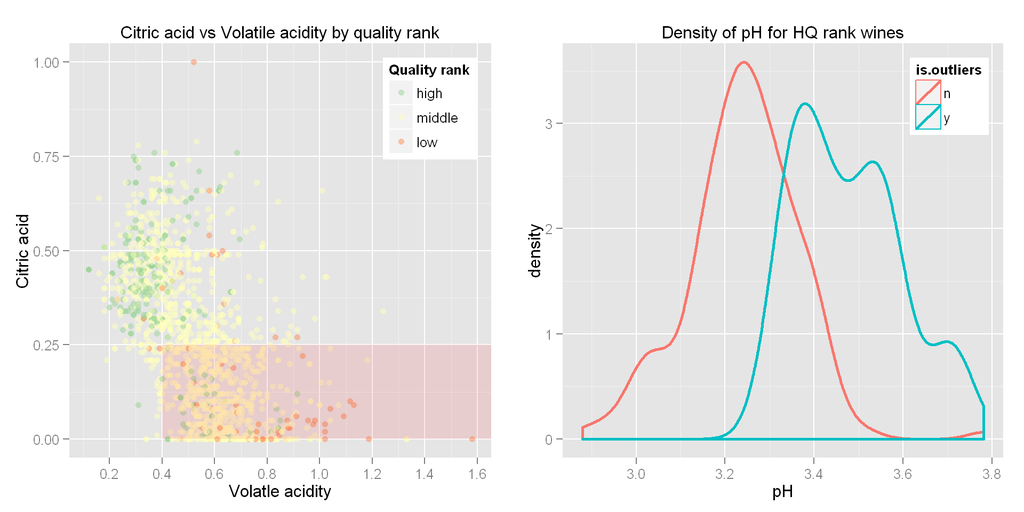

```r
final_plot_tree_1 = ggplot()+
  geom_point(alpha = 0.5,
             data = rw,
             aes(x=volatile.acidity,
                 y = citric.acid,
                 color = quality.rank),
             size=2)+
  scale_x_continuous(breaks = seq(0,1.6,0.2))+
  ylab("Citric acid")+
  xlab("Volatle acidity")+
  ggtitle("Citric acid vs Volatile acidity by quality rank")+
  scale_color_brewer(palette="Spectral",
                     type = 'div',
                     guide = guide_legend(title = 'Quality rank',
                                          reverse = T))+
  geom_rect(aes(xmin=0.4,xmax=Inf,ymin=0,ymax=0.25),alpha=0.1,fill="red") +
  theme(plot.title = element_text(size=12),
        legend.justification=c(1,1),
        legend.position=c(1,1))


final_plot_tree_2 = density_plot_func(d = hqrw,
                  col = "is.outliers",
                  x_str = "pH",
                  xl = "pH",
                  t = "Density of pH for HQ rank wines")+
  theme(plot.title = element_text(size=12),
        legend.justification=c(1,1),
        legend.position=c(1,1))

grid.arrange(final_plot_tree_1, final_plot_tree_2, ncol=2)
```

HQ wines mainly have low level of volatile acidity and citric acid level between 0.25 and 0.75. However, some samples of HQ wines has different parameters.

Additional research of HQ wines subset and its outliers show interesting dependencies. If wines have high level of quality even in “red zone”, then pH value significantly increase. To reduce influence of volatile acidity on quality need to increase quantity of antioxidants. As a result we receive higher value of pH for HQ wines with high level of acidity. Antioxidants may be such data set parameters as Chlorides, Total and Free SO2 and Sulphates.

### Summary

Three final plots demonstrate dependance wines quality from the several characteristics. As a result, the same quality wine level may have different proportions of SO2, sulphates, pH, acidity and alcohol.

Main findings and trends of red wine data set:

- high quality wines have higher level of alcohol;
- at the same time Volatile acidity level shouldn’t be higher than 0.4. In the case of high volatile acidity level need to raise pH value;
- most of HQ wines consist from 0.25 to 0.75 citric acid;
- sulphates level make wines more quality. However, they should lie under the 1.0 value;
- HQ wines don’t consist Total SO2 more than 50 g/dm^3.

Another interesting thing is poor wines has a high pH level, but in the third plot we saw opposite evidence. I think pH level makes balance to provide good taste for wine.

For example, we have pretty similar values of pH for the different wine quality. in main data set for poor wines: Min. 1st Qu. Median Mean 3rd Qu. Max. 2.740 3.300 3.380 3.384 3.500 3.900

in HQ wines subset for “outliers”: Min. 1st Qu. Median Mean 3rd Qu. Max. 3.320 3.370 3.460 3.476 3.560 3.720

So, we can’t examine wine quality based only on the single parameter.

# Reflection

It was interesting to explore this data set. I’m not expert of wines. I even don’t drink. So, it was fascinatingly to determine which characteristics make wines good or poor without tasting :)

When I used different plot types I received more complex information about the same variable. (e.g. boxplot show different details rather than histogram or density plot). I never used boxplots before. So, it’s very useful tool to describe variable.

Exploring subset of HQ wines and outliers in the end of data analysis discovered some interesting dependencies. After that, I realized how parameters contribute to each other.

During analysis I faced such difficulties as:

- some R functions. I used manual, blogs etc. For example, to set parameters of ggpairs function;
- I don’t fully understood pH role in data set.

Moreover, there are several tricky moment in the data set:

- presence of input data errors (says in data description);
- a few observations of poor and high quality wines;
- all wines produced in the same region of Portugal. Thus, wines from France or the US may have other character istic values.

In this data set I didn’t find such features like age of wine, grape, soil acidity etc. Feasibly, one of them could show interesting correlations.

Possible future researches:

- go deeper in data set and explore such features as residual sugar, fixed acidity;
- continue to explore outliers and examine poor quality wines;
- apply different methods of regression analysis.

EDA really exciting and may take a huge time to research. You should to know time to stop.